# AS3-1: 數位偵探

第 13 組

2019-03-11 14:31:41

犯罪是一個國際關注的問題，但它在不同的國家以不同的方式記錄和處理。 在美國，聯邦調查局（FBI）記錄了暴力犯罪和財產犯罪。 此外，每個城市都記錄了犯罪行為，一些城市發布了有關犯罪率的數據。 伊利諾伊州芝加哥市從2001年開始在線發布犯罪數據。

芝加哥是美國人口第三多的城市，人口超過270萬。在這個作業裡面，我們將關注一種特定類型的財產犯罪，稱為「汽車盜竊」，我們將使用R中的一些基本數據分析來了解芝加哥的汽車盜竊紀錄。請載入文件“data/mvtWeek1.csv”：以下是各欄位的描述：

- `ID`: a unique identifier for each observation
- `Date`: the date the crime occurred
- `LocationDescription`: the location where the crime occurred
- `Arrest`: whether or not an arrest was made for the crime (TRUE if an arrest was made, and FALSE if an arrest was not made)
- `Domestic`: whether or not the crime was a domestic crime, meaning that it was committed against a family member (TRUE if it was domestic, and FALSE if it was not domestic)
- `Beat`: the area, or “beat” in which the crime occurred. This is the smallest regional division defined by the Chicago police department.
- `District`: the police district in which the crime occured. Each district is composed of many beats, and are defined by the Chicago Police Department.
- `CommunityArea`: the community area in which the crime occurred. Since the 1920s, Chicago has been divided into what are called “community areas”, of which there are now 77. The community areas were devised in an attempt to create socially homogeneous regions.
- `Year`: the year in which the crime occurred.
- `Latitude`: the latitude of the location at which the crime occurred.
- `Longitude`: the longitude of the location at which the crime occurred.

### Section-1 Loading the Data

【1.1】How many rows of data (observations) are in this dataset?

```r
#191641
data=read.csv("mvtWeek1.csv")
nrow(data)
```

```
[1] 191641
```

檢查各欄位的資料格式

```r
#
str(data)
```

```
'data.frame':   191641 obs. of  11 variables:
 $ ID                 : int  8951354 8951141 8952745 8952223 8951608 8950793 8950760 8951611 8951802 8950706 ...
 $ Date               : Factor w/ 131680 levels "1/13/01 0:00",..: 27470 27469 27469 27469 27468 27467 27466 27465 27463 27462 ...
 $ LocationDescription: Factor w/ 78 levels "ABANDONED BUILDING",..: 72 72 62 72 72 72 72 72 72 72 ...
 $ Arrest             : logi  FALSE FALSE FALSE FALSE FALSE TRUE ...
 $ Domestic           : logi  FALSE FALSE FALSE FALSE FALSE FALSE ...
 $ Beat               : int  623 1213 1622 724 211 2521 423 231 1021 1215 ...
 $ District           : int  6 12 16 7 2 25 4 2 10 12 ...
 $ CommunityArea      : int  69 24 11 67 35 19 48 40 29 24 ...
 $ Year               : int  2012 2012 2012 2012 2012 2012 2012 2012 2012 2012 ...
 $ Latitude           : num  41.8 41.9 42 41.8 41.8 ...
 $ Longitude          : num  -87.6 -87.7 -87.8 -87.7 -87.6 ...
```

類別(Factor) versus 字串(Character)

【1.2】How many variables are in this dataset?

```r
#11
ncol(data)
```

```
[1] 11
```

【1.3】Using the “max” function, what is the maximum value of the variable “ID”?

```r
#9181151
data$ID[which.max(data$ID)]
```

```
[1] 9181151
```

```r
#method2
max(data$ID,na.rm = FALSE)
```

```
[1] 9181151
```

【1.4】 What is the minimum value of the variable “Beat”?

```r
#111
data$Beat[which.min(data$Beat)]
```

```
[1] 111
```

```r
#method2
min(data$Beat,na.rm = FALSE)
```

```
[1] 111
```

【1.5】 How many observations have value TRUE in the Arrest variable (this is the number of crimes for which an arrest was made)?

```r
#15536
a=subset(data,Arrest=="TRUE")
nrow(a)
```

```
[1] 15536
```

```r
#method2
sum(data$Arrest=="TRUE")
```

```
[1] 15536
```

```r
#method3
summary(data)
```

```
       ID                      Date                            LocationDescription
 Min.   :1310022   5/16/08 0:00  :    11   STREET                        :156564
 1st Qu.:2832144   10/17/01 22:00:    10   PARKING LOT/GARAGE(NON.RESID.): 14852
 Median :4762956   4/13/04 21:00 :    10   OTHER                         :  4573
 Mean   :4968629   9/17/05 22:00 :    10   ALLEY                         :  2308
 3rd Qu.:7201878   10/13/01 22:00:     9   GAS STATION                   :  2111
 Max.   :9181151   10/26/01 22:00:     9   DRIVEWAY - RESIDENTIAL        :  1675
                   (Other)       :191582   (Other)                       :  9558
   Arrest         Domestic            Beat         District     CommunityArea
 Mode :logical   Mode :logical   Min.   : 111   Min.   : 1      Min.   : 0
 FALSE:176105    FALSE:191226    1st Qu.: 722   1st Qu.: 6      1st Qu.:22
 TRUE :15536     TRUE :415       Median :1121   Median :10      Median :32
                                 Mean   :1259   Mean   :12      Mean   :38
                                 3rd Qu.:1733   3rd Qu.:17      3rd Qu.:60
                                 Max.   :2535   Max.   :31      Max.   :77
                                                NA's   :43056   NA's   :24616
      Year         Latitude      Longitude
 Min.   :2001   Min.   :41.6   Min.   :-87.9
 1st Qu.:2003   1st Qu.:41.8   1st Qu.:-87.7
 Median :2006   Median :41.9   Median :-87.7
 Mean   :2006   Mean   :41.8   Mean   :-87.7
 3rd Qu.:2009   3rd Qu.:41.9   3rd Qu.:-87.6
 Max.   :2012   Max.   :42.0   Max.   :-87.5
                NA's   :2276   NA's   :2276
```

【1.6】 How many observations have a LocationDescription value of ALLEY?

```r
#2308
sum(data$LocationDescription=="ALLEY")
```

```
[1] 2308
```

### Section-2 Understanding Dates in R

【2.1】 In what format are the entries in the variable Date?

- Month/Day/Year Hour:Minute
- Day/Month/Year Hour:Minute
- Hour:Minute Month/Day/Year
- Hour:Minute Day/Month/Year

```r
#Month/Day/Year Hour:Minute
head(data$Date)
```

```
[1] 12/31/12 23:15 12/31/12 22:00 12/31/12 22:00 12/31/12 22:00 12/31/12 21:30
[6] 12/31/12 20:30
131680 Levels: 1/13/01 0:00 1/13/01 1:00 1/13/01 1:40 1/13/01 10:00 ... 9/30/12 8:30
```

```r
dateconverted=as.POSIXct(data$Date,format="%m/%d/%y %H:%M")
```

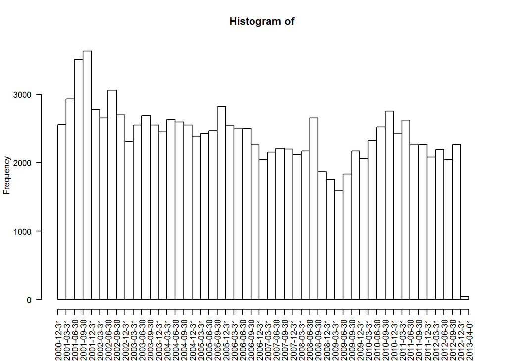

```r
par(cex=0.7)
hist(dateconverted,"quarter",las=2,freq=T,xlab="")
```

```r
table( format(dateconverted,'%u') )
```

```
    1     2     3     4     5     6     7
16640 16338 16830 16462 17837 16547 16036
```

```r
table(format(dateconverted,'%m'))
```

```
   01    02    03    04    05    06    07    08    09    10    11    12
 9879  7856  9799  9139  9959  9675 10404 10104  9829 10573  9511  9962
```

```r
table(weekday=format(dateconverted,'%u'), month=format(dateconverted,'%m'))
```

```
       month
weekday   01   02   03   04   05   06   07   08   09   10   11   12
      1 1476 1118 1356 1399 1458 1285 1468 1444 1371 1534 1356 1375
      2 1408 1160 1414 1215 1394 1263 1502 1386 1290 1504 1424 1378
      3 1330 1198 1436 1263 1389 1529 1478 1546 1330 1531 1339 1461
      4 1402 1093 1416 1228 1476 1366 1454 1420 1449 1398 1241 1519
      5 1490 1150 1474 1453 1511 1545 1571 1595 1514 1558 1432 1544
      6 1428 1082 1408 1369 1389 1361 1468 1337 1439 1504 1359 1403
      7 1345 1055 1295 1212 1342 1326 1463 1376 1436 1544 1360 1282
```

```r
table(weekday=format(dateconverted,'%u'), hour=format(dateconverted,'%H'))
```

```
       hour
weekday   00   01   02   03   04   05   06   07   08   09   10   11   12   13   14   15
      1 1114  526  439  309  241  338  452  673  800  745  591  425  685  504  614  642
      2 1026  477  369  272  259  331  495  685  713  722  573  460  692  474  545  660
      3 1098  479  370  275  244  356  540  678  810  747  561  446  753  490  557  650
      4 1117  489  437  279  236  315  507  665  793  762  545  429  665  461  504  642
      5 1141  593  460  338  289  366  516  726  741  784  559  508  743  491  596  690
      6 1252  745  586  508  407  307  344  385  532  604  591  462  687  459  586  681
      7 1224  767  651  486  370  277  291  277  354  510  549  489  734  496  556  640
       hour
weekday   16   17   18   19   20   21   22   23
      1  697  773  923  916 1009 1102 1235  887
      2  667  802  934  911 1056 1101 1228  886
      3  670  793  981  926 1081 1091 1282  952
      4  707  756  902  903 1039 1049 1307  953
      5  719  812  970  995 1065 1143 1403 1189
      6  657  664  824  874  955 1044 1312 1081
      7  637  711  841  882 1050 1026 1271  947
```

【2.2】 What is the month and year of the median date in our dataset?

```r
#2006-05
#轉換成日期格式
median(dateconverted,na.rm=T)
```

```
[1] "2006-05-29 21:00:00 CST"
```

【2.3】 In which month did the fewest motor vehicle thefts occur?

```r
#Feb
#新增month變數到data
data$month=months(dateconverted)
table(data$month)
```

```
  一月   七月   九月   二月   八月 十一月 十二月   十月   三月   五月   六月   四月
  9879  10404   9829   7856  10104   9511   9962  10573   9799   9959   9675   9139
```

```r
which.min(table(data$month))
```

```
二月
   4
```

【2.4】 On which weekday did the most motor vehicle thefts occur?

```r
#Fri
#新增weekday變數到data
data$weekday=weekdays(dateconverted)
table(data$weekday)
```

```
星期一 星期二 星期三 星期五 星期六 星期日 星期四
 16640  16338  16830  17837  16547  16036  16462
```

```r
which.max(table(data$weekday))
```

```
星期五
     4
```

【2.5】 Which month has the largest number of motor vehicle thefts for which an arrest was made?

```r
#Jan
arrestmonth=subset(data,Arrest==TRUE)
table(arrestmonth$month)
```

```
  一月   七月   九月   二月   八月 十一月 十二月   十月   三月   五月   六月   四月
   860    839    761    745    807    736    847    819    803    745    730    744
```

```r
which.max(table(arrestmonth$month))
```

```
一月
   1
```